# Calanus life from the CCA point of view

Вадим Хайтов

## Первичные данные

1. Исходную матрицу обилий и значений параметров среды, которую я получил от Коли (файл Calanus_2020.xlsx) я преобразовал в длинный формат (*файл Calanus_2020_tidy_NA_filled.xlsx*).
2. В случае с обилиями калянусов все пробы, которые имели обилие равное NA, я рассматривал как отсутствующие пробы, они в анализе не принимали участия (в результате получился файл *Calanus_tidy.csv*, с которым я и работал).
3. В случае с параметрами среды в анализ были включены усредненные значения параметров, полученные по следующему правилу. Для каждой планктонной пробы были вычислены средние значения параметра среды в соответствии с горизонтами глубин:
- Для горизонта облова 0-10 м. усреднялись измерения на глубине 0, 5, 10 м
- Для горизонта облова 10-25 м. усреднялись измерения на глубине 10, 15, 25 м
- Для горизонта облова 25 - дно усреднялись измерения на глубине 25, 50, 65 м
- Параметры, измеренные на пяти горизонтах станции D3, приписывались каждому горизонту облова без усреднений.

Усреднение проводилось, если было хотя бы одно значение, измеренное при взятии планктонной пробы: например при измерении температуры (16.0 NA NA) в итоговую оценку шло 16, или (1.6 NA 0.0) в итоговую оценку шло 0.8.

Однако, на станции D1 если измерение не было сделано, но на двух соседних декадах это измерение делали, то вместо NA ставили среднее значение между соседними измерениями.

**ВНИМАНИЕ** Этот кусок надо проверить. Для этого надо открыть файл **Calanus_2020_tidy_NA_replaced_by_means.xlsx** и там посмотреть на ячейки, залитые синим цветом.

На станции D3 NA заполняли средним значением параметра за все годы в данный месяц на данном горизонте глубины.Эти ячейки выделены коричневым. НАДО ПРОВЕРИТЬ (файл Calanus_2020_tidy_NA_replaced_by_means.xlsx)

В результате всех доработок был получен файл *Environment_tidy.csv*, с которым я и работал.

4. Для соблюдения требований ССА пришлось удалить все строчки, в которых было хотя бы одно значение `NA`. **Внимание!** Это привело к существенному сокращению количества проб, использованных для анализа. Если в полной матрице было 1620 пробы, то после всех описанных выше действий осталось 492 проб. В полном наборе проб были использованы данные 1998 - 2019 годов, а в сокращенном варианте материал 2012, 2016, 2009, 2010, 2018, 2019, 2015, 2017, 2013, 2011, 2014. Количество проб для каждого из годов следующее:

| Year | D1 | D3 |
| --- | --- | --- |
| 2009 | 25 | NA |
| 2010 | 45 | NA |
| 2011 | 31 | NA |
| 2012 | 20 | 11 |
| 2013 | 30 | 6 |
| 2014 | 23 | 9 |
| 2015 | 31 | 16 |
| 2016 | 45 | 8 |
| 2017 | 52 | 26 |
| 2018 | 37 | 23 |
| 2019 | 45 | 9 |

## Методика визуализации сезонных изменений связи популяции Calanus с параметрами среды

Был проведен канонический корреспндентный анализ (CCA) (ter Braak 1994, Legendre & Legendre 2012). В качестве зависимой матрицы была использована матрица, столбцами которой (variables) были стадии жизненного цикла Calanus (Np, CI, CII, CIII, CIV, CV, CM, CF) строками матрицы были сборы, каждая строка - отдельная проба. В ячейках матрицы располагались значения обилия соответствующей стадии в данной пробе. Вторая матрица, использованная в CCA, характеризовала следующие параметры среды, описанные для каждой пробы: Глубина (среднее значение глубины для протяжки сетью), соленость, температура и концентрация хлорофилла, измеренные на тех же горизонтах глубины, где была взята проба. Дополнительно, в качестве дискретного предиктора, в модель CCA была включена точка взятия проб (две градации: D1 vs D3). В анализе были использованы только те пробы, для которых были проведены оценки всех элементов обеих матриц (всего 492 проб).

Для оценки статистической значимости модели CCA в целом, значимости отдельных constrained axes и конкретных предикторов был применен пермутационный метод (Borcard et al., 2011). Для оценки уровня значимости во всех анализах проводилось 9999 пермутаций.

Вычисления были проведены с использованием функций пакета vegan (Oksanen et al, 2019) для языка статистического программирования R 3.6.2 (R Core Team, 2019).

| term | df | ChiSquare | statistic | p.value |
| --- | --- | --- | --- | --- |
| Model | 5 | 0.435643 | 33.00314 | 1e-04 |
| Residual | 486 | 1.283045 | NA | NA |

| term | df | ChiSquare | statistic | p.value |
| --- | --- | --- | --- | --- |
| CCA1 | 1 | 0.2600064 | 98.4869214 | 0.0001 |
| CCA2 | 1 | 0.1559051 | 59.0547442 | 0.0001 |
| CCA3 | 1 | 0.0128725 | 4.8759142 | 0.0055 |
| CCA4 | 1 | 0.0056682 | 2.1470507 | 0.1578 |
| CCA5 | 1 | 0.0011908 | 0.4510676 | 0.8355 |
| Residual | 486 | 1.2830447 | NA | NA |

| term | df | ChiSquare | statistic | p.value |
| --- | --- | --- | --- | --- |
| Depth | 1 | 0.0306720 | 11.618121 | 0.0001 |
| Temp | 1 | 0.1676694 | 63.510893 | 0.0001 |
| Station | 1 | 0.0069367 | 2.627518 | 0.0210 |
| Sal | 1 | 0.0210921 | 7.989390 | 0.0001 |
| Chl | 1 | 0.0469168 | 17.771437 | 0.0001 |
| Residual | 486 | 1.2830447 | NA | NA |

## Визуализация результатов

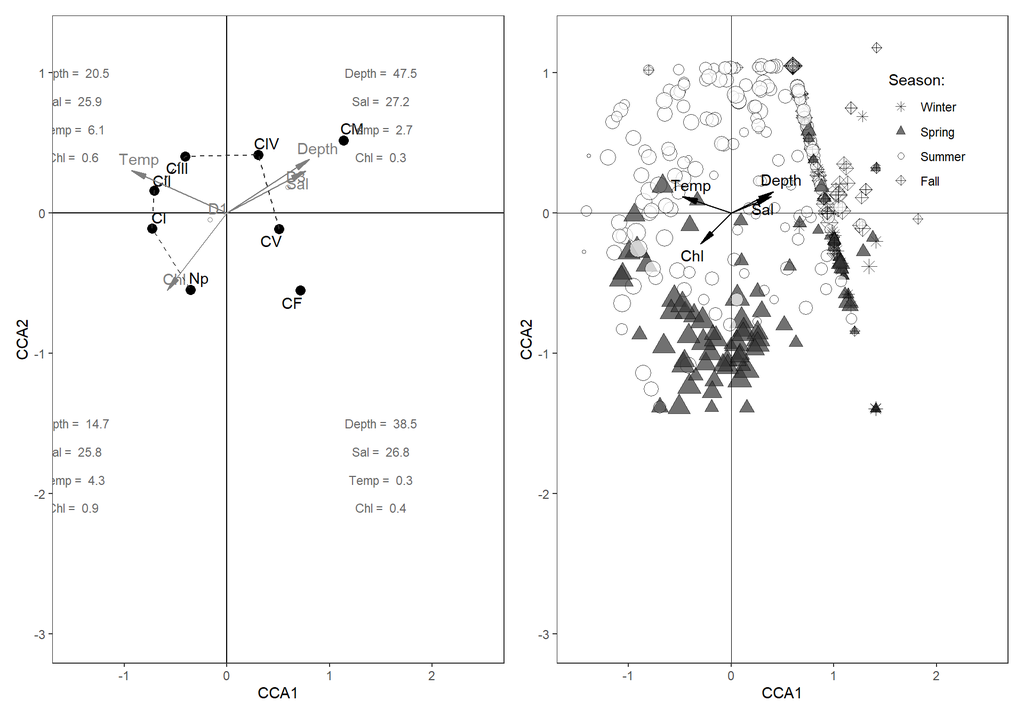

Ordination of life cycle stages (left) and samples (right) in the space of constrained axes. The mean values of environmental parameters calculated for points situated in each ordination quadrant are presented on the left pannel, the size of points on the right pannel is proportional to *Calanus* abundance.

Следующий не очень нужный рисунок,он показывает, что на двух станциях закономерности более или менее сходные.

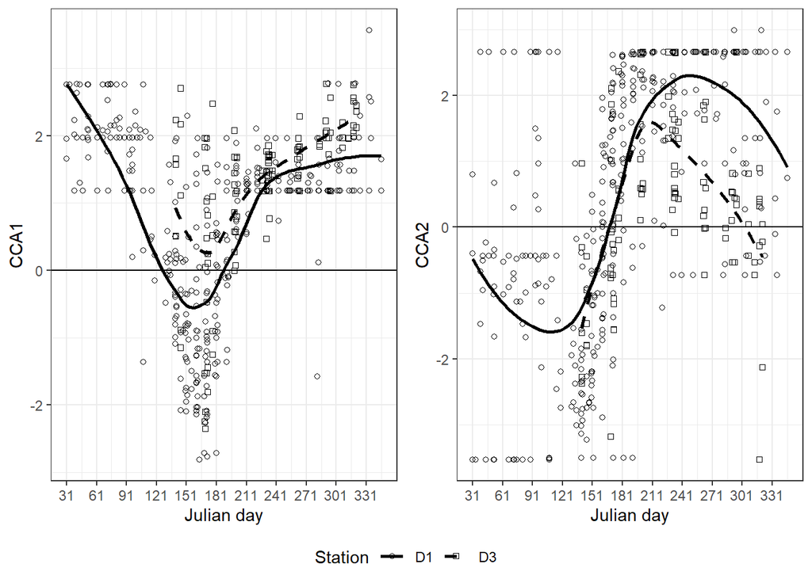

Seasonal changes in CCA1 and CCA2 values at two sampling stations. Curves represent LOESS smoothers.